# Geostatistical Modelling of Soil Organic Carbon in Bavaria - (SoilGeoStats)

Adebola David Adedayo

# 1. Introduction and Background

Soil Organic Carbon (OC) plays a critical role in agricultural productivity and regional climate mitigation strategies. Soil research is still reliant on traditional point-based sampling, but it does not provide the continuous coverage required for spatial decision-making.  
Geostatistical methods, such as Inverse Distance Weighting (IDW) and Kriging, address this by modelling the spatial autocorrelation of soil point observations to predict values at unsampled locations.

This vignette presents a reproducible geostatistical data pipeline evaluating OC distribution across the state of Bavaria, Germany. Using a dataset obtained from the official [LUCAS 2018 Topsoil Survey](https://esdac.jrc.ec.europa.eu/content/lucas-2018-topsoil-data) compiled by the European Soil Data Centre (ESDAC), this study shows how **`SoilGeoStats`** package simplifies spatial data ingestion, exploratory statistics, and continuous grid surface interpolation within an object-oriented R framework using S3 method dispatching.  
`SoilGeoStats` will be useful to spatial data analysts, environmental scientists, soil ecologists, and researchers who work with soil point datasets and need a quick, reproducible pipeline to clip, validate, and carry out geostatistical interpolation.

# 2. Data Description

The LUCAS 2018 Topsoil dataset used in this work contains soil properties such as pH, organic carbon content, phosphorus, potassium, and nitrogen, covering the European Union and the United Kingdom.  
This dataset originally consisted of 18,984 samples, taken from 0-20 cm depth in a **CSV file**.

```r
library(SoilGeoStats)
library(sf)
library(ggplot2)
```

# 3. Analysis Workflow

The study workflow showcases standard GIS methods upgraded into an object-oriented R programming framework utilizing S3 method dispatching.

## 3.1. Ingestion, Validation, and Spatial Clipping

The first stage of the analysis pipeline ingests unprojected WGS84 point records and intersects them against a regional vector boundary shapefile of Bavaria (EPSG: 25832) obtained from [GADM](https://gadm.org/data.html), stored directly within the package’s `inst/extdata` directory. The function automatically resolves coordinate mismatches, clips observations to the study area, and appends projected UTM coordinates.

```r
# Ingest and spatially process the dataset using system file paths
soil_data_raw <- load_and_validate_data(
    file_path = system.file("extdata", "soil_data/LUCAS-SOIL-2018.csv", package = "SoilGeoStats"), # file path to soil data
    x_col = "TH_LONG", # X coordinate column
    y_col = "TH_LAT", # Y coordinate column
    target_col = "OC", # the variable to be modelled
    covariate_cols = c("N", "Elev"), # covariate variables for regression kriging
    shape_path = system.file("extdata", "shape_file/Bav_Boundary.shp", package = "SoilGeoStats") # file path to boundary shapefile
)
# Filter to essential columns only
soil_data_clipped <- dplyr::select(soil_data_raw, OC, N, Elev, geometry)

# View spatial features layout
print(head(soil_data_clipped))
```

```
#> Simple feature collection with 6 features and 3 fields
#> Geometry type: POINT
#> Dimension:     XY
#> Bounding box:  xmin: 641884.4 ymin: 5290469 xmax: 692831.1 ymax: 5427076
#> Projected CRS: ETRS89 / UTM zone 32N
#>        OC   N Elev                 geometry
#> 1729 51.0 5.8  761 POINT (641884.4 5290469)
#> 1730 13.0 1.6  409 POINT (672323.7 5410898)
#> 1731 47.2 4.8  480 POINT (681066.7 5352983)
#> 1732 36.0 3.8  405 POINT (686576.5 5391068)
#> 1733 14.0 1.6  482 POINT (686111.4 5427076)
#> 1734 14.9 1.7  484 POINT (692831.1 5371136)
```

**Column Definitions:**

`OC` (Organic Carbon Content): the primary target variable,representing the mass fraction of organic carbon in the topsoil (g/kg).

`N` (Nitrogen): an environmental covariate representing the total nitrogen content (g/kg), highly correlated with organic matter accumulation.

`Elev` (Elevation): A topographic covariate representing altitude above sea level (meters).

`geometry` (Spatial Features): Point geometries in the ETRS89 / UTM zone 32N grid system.

### Visualizing the Spatial Sample Distribution

Before executing the interpolation surfaces, the cleaned point observation locations are mapped to visualize how evenly the physical soil samples are dispersed across the Bavarian state boundary:

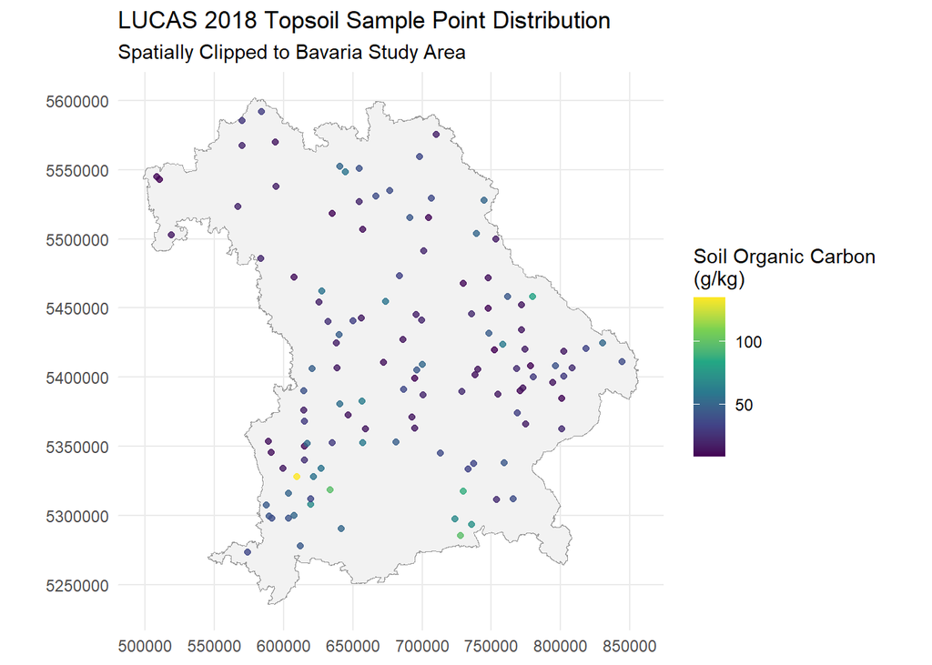

```r
# Load Bavaria boundary polygon
bavaria_mask <- sf::st_read(system.file("extdata", "shape_file/Bav_Boundary.shp", package = "SoilGeoStats"), quiet = TRUE)

# Plot point distributions
ggplot() +
  geom_sf(data = bavaria_mask, fill = "gray95", color = "gray60") +
  geom_sf(data = soil_data_clipped, aes(color = OC), size = 1.5, alpha = 0.8) +
  scale_color_viridis_c(name = "Soil Organic Carbon\n(g/kg)", option = "viridis") +
  coord_sf(datum = sf::st_crs(25832)) +
  labs(title = "LUCAS 2018 Topsoil Sample Point Distribution",
       subtitle = "Spatially Clipped to Bavaria Study Area") +
  theme_minimal() +
  theme(legend.position = "right")
```

## 3.2. Exploratory Spatial Data Analysis

Before interpolating, a distance metrics alongside basic summary statistics (such as mean, median, variance) are calculated to analyze point spacing bounds and global distribution skewness.

```r
# Execute exploratory spatial data analysis of target variable (OC)
eda_metrics <- exploratory_data_analysis(spatial_data = soil_data_clipped, target_col = "OC")

# Display compiled summary metrics
cat("Total Observations Inside Mask  :", eda_metrics$total_points, "points\n")
```

```
#> Total Observations Inside Mask  : 124 points
```

```r
cat("Minimum Point Spacing Interval  :", round(eda_metrics$minimum_sampling_interval_meters / 1000, 2), "km\n")
```

```
#> Minimum Point Spacing Interval  : 2.83 km
```

```r
cat("Maximum Study Extent Diameter   :", round(eda_metrics$maximum_sampling_interval_meters / 1000, 2), "km\n")
```

```
#> Maximum Study Extent Diameter   : 361.43 km
```

```r
cat("Sample Mean of Target Column:", eda_metrics$variable_mean, "\n")
```

```
#> Sample Mean of Target Column: 32.99839
```

```r
cat("Sample Median of Target Column:", eda_metrics$variable_median, "\n")
```

```
#> Sample Median of Target Column: 29.45
```

```r
cat("Sample Variance of Target Column:", eda_metrics$variable_variance, "\n")
```

```
#> Sample Variance of Target Column: 470.3382
```

**Statistical Significance of Results:**

- Total Observations (`total_points`): Represents the observation sample size available within the geographic region.
- Minimum Point Spacing Interval (`minimum_sampling_interval_meters`): Signifies the absolute finest spatial resolution of the raw data collection grid. This metric tells us how close the nearest neighbor points are.
- Maximum Study Extent Diameter (`maximum_sampling_interval_meters`): Measures the absolute maximum geographic distance stretching across the study polygon. It is critical for constraining interpolation search radii.
- Sample Mean (`variable_mean`): This provides the global mathematical baseline of Topsoil Organic Carbon across Bavaria.
- Sample Median (`variable_median`): This identifies the exact midpoint of the data distribution. Comparing the mean directly to the median allows us to detect statistical skewness.  
  *If the mean is significantly higher than the median, it indicates a right-skewed distribution, meaning the landscape has localized “hotspots” of high carbon storage among lower baseline agricultural values*.
- Sample Variance (`variable_variance`): Measures the global dispersion and heterogeneity of the Soil Organic Carbon data. Higher variance values signal an environmentally complex region with significant localized shifts, highlighting why advanced geostatistical modeling (like Regression Kriging) is necessary over simple averages.

## 3.3. Spatial Interpolation (S3 Object Construction)

Two interpolation approaches - deterministic **Inverse Distance Weighting (IDW)** and hybrid **Regression Krigging (RK)** model incorporating Nitrogen and Elevation covariates, are compared.  
Both engines return the custom S3 `spatial_grid` class.

```r
# 1. Deterministic Inverse Distance Weighting Interpolation
idw_grid_obj <- interpolate_idw_surface(spatial_data = soil_data_clipped, target_col = "OC", power = 2.0)

# 2. Multi-Variable Regression Kriging (Using Nitrogen and Elevation Covariates)
rk_grid_obj  <- interpolate_regression_kriging(spatial_data = soil_data_clipped,
                                                target_col = "OC",
                                                covariate_cols = c("N", "Elev"))
```

## 3.4. S3 Methods Dispatching: Metadata and Cross-Validation

By simply calling standard R commands like `print()` and `summary()`, R automatically resolves the custom S3 hierarchy stamp, routing the data directly to the created leave-one-out cross-validation (LOOCV) calculations.

Object Metadata:

```r
# View S3 Metadata
print(idw_grid_obj) #View output of IDW interpolation
```

```
#> === Geostatistical Package Grid Object ===
#> Interpolation Method : IDW
#> Target Soil Property : OC
#> Grid Resolution      : 10000 meters
#> Total Active Nodes   : 1088 cells generated
#> ------------------------------------------
```

```r
print(rk_grid_obj) #View output of regression kriging
```

```
#> === Geostatistical Package Grid Object ===
#> Interpolation Method : Regression Kriging
#> Target Soil Property : OC
#> Grid Resolution      : 10000 meters
#> Total Active Nodes   : 1088 cells generated
#> ------------------------------------------
```

Interpolation Model Accuracy Assessments (LOOCV Results):

```r
# Execute Leave-One-Out Cross-Validation (LOOCV)
summary(idw_grid_obj) #Accuracy metrics of IDW interpolation
```

```
#> === Running Leave-One-Out Cross-Validation Engine ===
#> Evaluating Method: IDW
#>
#> --- Validation Performance Metrics ---
#> Mean Error (ME)        : 0.19312 (g/kg)
#> Root Mean Square Error : 19.93917 (g/kg)
#> ======================================
```

```r
summary(rk_grid_obj) #Accuracy metrics of regression kriging
```

```
#> === Running Leave-One-Out Cross-Validation Engine ===
#> Evaluating Method: Regression Kriging
#>
#> --- Validation Performance Metrics ---
#> Mean Error (ME)        : -0.35017 (g/kg)
#> Root Mean Square Error : 5.84593 (g/kg)
#> ======================================
```

## 3.5. Cartographic Visualizations

Finally, the custom S3 `plot()` method is explored. By integrating the study region’s polygon file path directly into the function, it automatically generates continuous map tile surfaces clipped cleanly to study region.

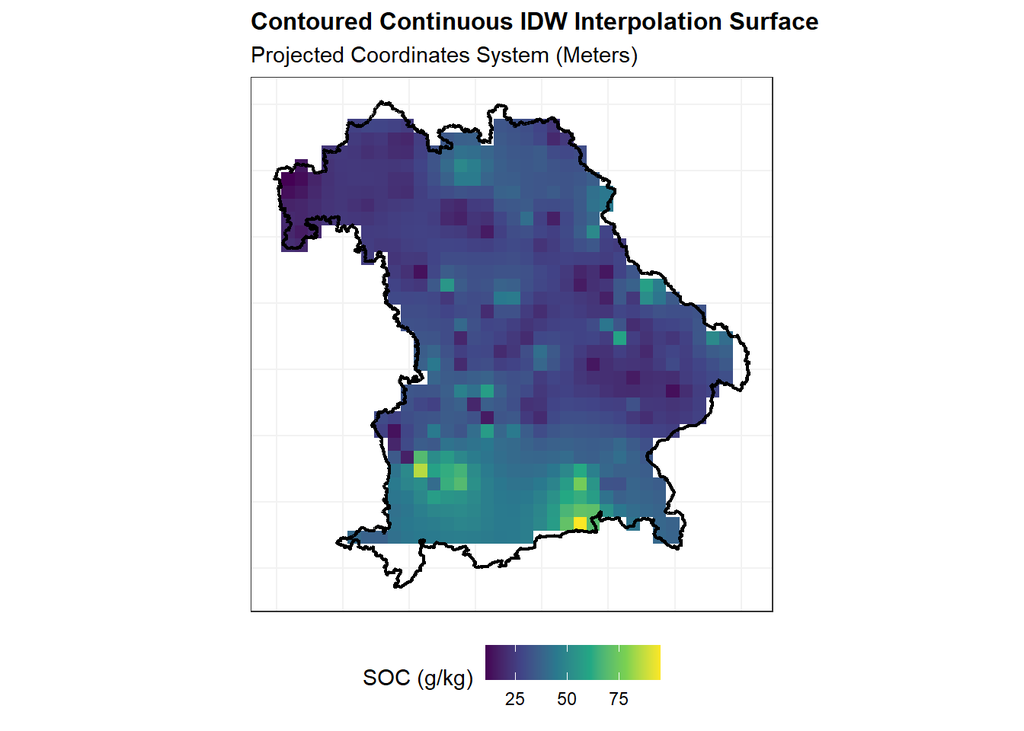

```r
# Extract internal shape path for vector outlines
bavaria_mask <- sf::st_read(system.file("extdata", "shape_file/Bav_Boundary.shp", package = "SoilGeoStats"), quiet = TRUE)

# Generate custom continuous map objects
map_idw <- plot(idw_grid_obj, boundary_data = bavaria_mask) #IDW surface
map_rk  <- plot(rk_grid_obj, boundary_data = bavaria_mask) #Regression Krigging Surface

# Render the final cartographic surfaces
print(map_idw)
```

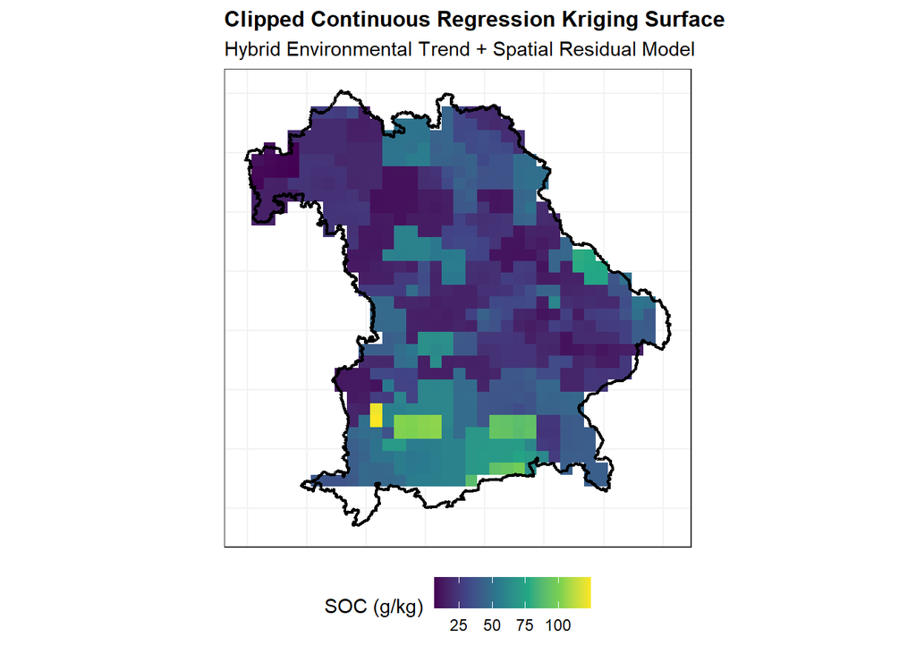

```r
print(map_rk)
```

# 4. Discussion of Results

The exploratory spatial data analysis revealed an asymmetry between the sample mean (33.00 g/kg) and median (29.45 g/kg), indicating a **right-skewed distribution** with localized high-value OC hotspots across Bavaria.

Evaluating the Leave-One-Out Cross-Validation metrics demonstrates a significant performance difference between the two interpolation models:

- **Inverse Distance Weighting (IDW)** produced a Root Mean Square Error (RMSE) of 19.94 g/kg. IDW relies solely on spatial proximity,therefore it struggles to capture non-linear local shifts in heterogeneous terrain like Bavaria.
- **Regression Kriging (RK)** drastically reduced prediction error to an RMSE of 5.85 g/kg (that is a 70% reduction in prediction error).

Combining environmental trend relationships (elevation gradients and total nitrogen) with residual kriging, Regression Kriging accounts for deterministic environmental drivers alongside spatial autocorrelation, yielding a superior continuous estimation surface for topsoil organic carbon.

# Reproducibility and Source Code

To ensure complete scientific transparency and computational reproducibility, the underlying package architecture, including the S3 class (`spatial_grid`), geostatistical interpolation methods, and cross-validation functions is fully open-source.

- **GitHub Repository:** [SoilGeoStats Source Code](https://github.com/adebolaadedayo/SoilGeoStats)
- **License:** MIT License.
- **Bug Reports & Contributions:** Issues or feature requests can be logged directly on the repository’s issue tracker.

# LLM Usage Declaration

I, the author declares the use of a Generative AI tool in the preparation of this assignment.  
Specifically, the AI tool (**Gemini**) was used for *technical code troubleshooting* and *Advanced Feature Integration* like the “Regression Krigging” and “Leave-One-Out Cross-Validation (LOOCV)”, but not for generating research data.  
All intellectual and creative work is original and has been conducted by the author without AI assistance.